# Análise de Breaking Bad

Eddie Kaleb

11 de julho de 2018

```r
library(tidyverse)
series_imdb <- read_csv("../../database/series_from_imdb.csv")
```

A série escolhida para análise foi Breaking Bad (2008-2013). Para isso, foi utilizado os dados do IMDB. Inicialmente, formulei duas perguntas a serem respondidas.

#### 1. Qual temporada de Breaking Bad foi melhor avaliada

Minha primeira impressão foi que a 5ª temporada teria a melhor média baseado na minha opinião sobre a série. Para isso extrai todos os dados dos episódios de todas as temporadas e calculei as médias.

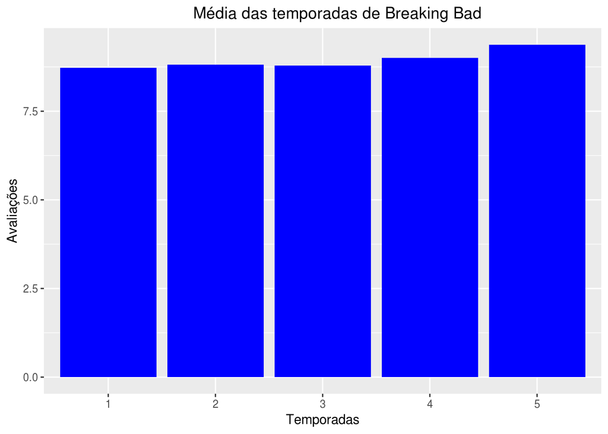

```r
series_imdb %>%
  filter(series_name %in% "Breaking Bad") %>%
  group_by(season) %>%
  summarise(season_mean = mean(UserRating)) %>%
  ggplot(aes(x=as.character(season), y=season_mean)) + geom_bar(stat="identity", aes(fill=season), fill="blue", show.legend=FALSE) +
  ggtitle("\t \t \t \t Média das temporadas de Breaking Bad") + xlab("Temporadas") + ylab("Avaliações")
```

Realmente a 5ª temporada foi a melhor avaliada, entretanto, percebe-se uma regularidade nas médias, o que não necessariamente quer dizer que todas as séries foram consideradas boas pelo público por não ter nenhuma informação que mostre a evolução das notas de forma precisa.

#### 2. As avalições (Breaking Bad) melhoraram ao decorrer das temporadas ou não?

Minha primeira impressão foi que ao decorrer das temporadas as avaliações fossem melhorar. Para isso, utilizei a mediana como medida para o gráfico de linhas, com isso, queria confrontar com a média utilizada na pergunta anterior, visualizando assim a evolução das avaliações de forma geral.

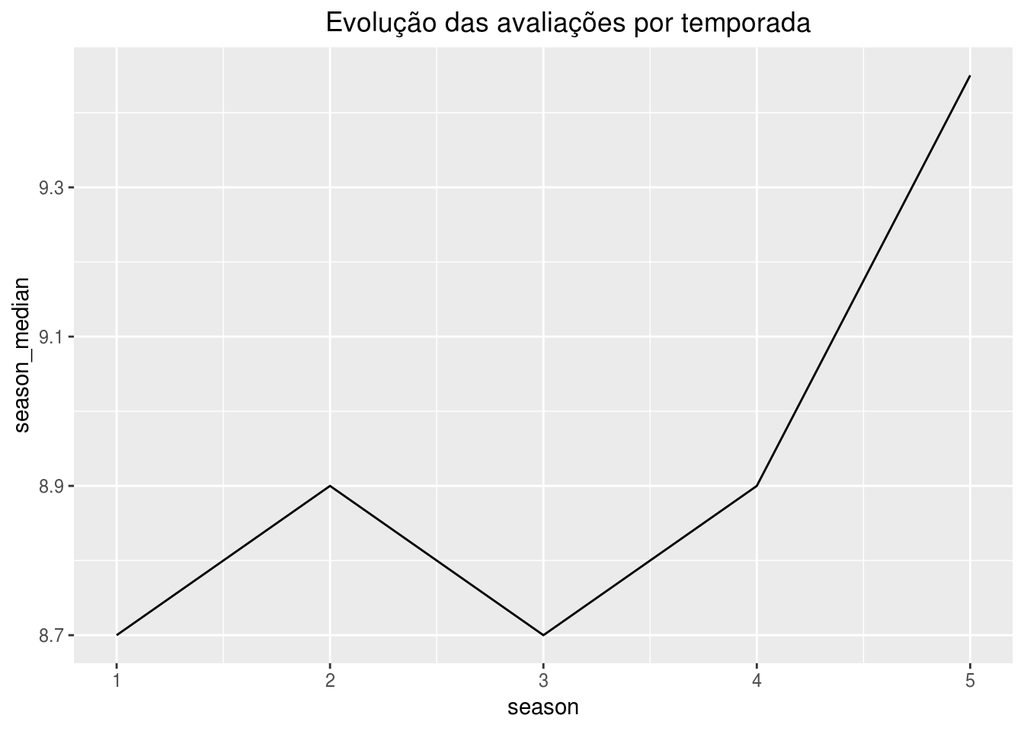

```r
series_imdb %>%
  filter(series_name %in% "Breaking Bad") %>%
  group_by(season) %>%
  summarise(season_median= median(UserRating))  %>%
  ggplot(aes(x=season, y=season_median)) + geom_line() +
  ggtitle("\t \t \t \t Evolução das avaliações por temporada")
```

A evolução das avaliações é perceptível, ocorrendo um grande salto nas avaliações entre a 4ª e 5ª temporada. É bastante justificável o resultado devido serem as duas últimas temporadas da série. Aliando esse resultado com o da pergunta anterior é possível afirmar com mais exatidão que a 5ª temporada foi a melhor de todas.